# Project 1: Explore and Prepare Data

CSE6242 - Data and Visual Analytics - Fall 2017 Due: Sunday, October 15, 2017 at 11:59 PM UTC-12:00 on T-Square

*Note: This project involves getting data ready for analysis and doing some preliminary investigations. Project 2 will involve modeling and predictions on the same dataset, and will be released at a later date. Both projects will have equal weightage towards your grade. You may reuse some of the preprocessing/analysis steps from Project 1 in Project 2.*

# Data

In this project, you will explore a dataset that contains information about movies, including ratings, budget, gross revenue and other attributes. It was prepared by Dr. Guy Lebanon, and here is his description of the dataset:

> The file [`movies_merged`](https://s3.amazonaws.com/content.udacity-data.com/courses/gt-cs6242/project/movies_merged) contains a dataframe with the same name that has 40K rows and 39 columns. Each row represents a movie title and each column represents a descriptor such as `Title`, `Actors`, and `Budget`. I collected the data by querying IMDb’s API (see [www.omdbapi.com](http://www.omdbapi.com/)) and joining it with a separate dataset of movie budgets and gross earnings (unknown to you). The join key was the movie title. This data is available for personal use, but IMDb’s terms of service do not allow it to be used for commercial purposes or for creating a competing repository.

# Objective

Your goal is to investigate the relationship between the movie descriptors and the box office success of movies, as represented by the variable `Gross`. This task is extremely important as it can help a studio decide which titles to fund for production, how much to bid on produced movies, when to release a title, how much to invest in marketing and PR, etc. This information is most useful before a title is released, but it is still very valuable after the movie is already released to the public (for example it can affect additional marketing spend or how much a studio should negotiate with on-demand streaming companies for “second window” streaming rights).

# Instructions

When you execute code within the notebook, the results appear beneath the code. Try executing this chunk by clicking the *Run* button within the chunk or by placing your cursor inside it and pressing *Cmd+Shift+Enter*.

```r
x = 1:10
print(x^2)
```

```
 [1]   1   4   9  16  25  36  49  64  81 100
```

Plots appear inline too:

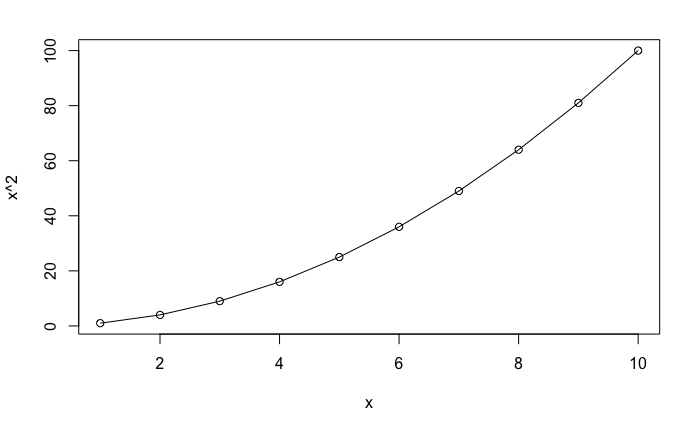

```r
plot(x, x^2, 'o')
```

```r
print('hello world!')
```

```
[1] "hello world!"
```

Please complete all the tasks below by implementing code chunks that have a `TODO` comment in them, running all code chunks so that output and plots are displayed, and typing in answers to each question (**Q:** …) next to/below the corresponding answer prompt (**A:**). Feel free to add code chunks/show additional output to support any of the answers.

When you are done, you will need to submit the final R markdown file (as **pr1.Rmd**) with all code chunks implemented and executed, and all text responses written in. You also need to submit a PDF export of the markdown file (as **pr1.pdf**), which should show your code, output, plots and written responses–this will be your project report. Compress these two files into a single .zip archive and upload it on T-Square.

# Setup

## Load data

Make sure you’ve downloaded the [`movies_merged`](https://s3.amazonaws.com/content.udacity-data.com/courses/gt-cs6242/project/movies_merged) file and it is in the current working directory. Now load it into memory:

```r
load('movies_merged')
cat("Dataset has", dim(movies_merged)[1], "rows and", dim(movies_merged)[2], "columns", end="\n", file="")
```

```
Dataset has 40789 rows and 39 columns
```

This creates an object of the same name (`movies_merged`). For convenience, you can copy it to `df` and start using it:

```r
df = movies_merged
cat("Column names:", end="\n", file="")
```

```
Column names:
```

```r
colnames(df)
```

```
 [1] "Title"             "Year"              "Rated"             "Released"          "Runtime"           "Genre"             "Director"          "Writer"
 [9] "Actors"            "Plot"              "Language"          "Country"           "Awards"            "Poster"            "Metascore"         "imdbRating"
[17] "imdbVotes"         "imdbID"            "Type"              "tomatoMeter"       "tomatoImage"       "tomatoRating"      "tomatoReviews"     "tomatoFresh"
[25] "tomatoRotten"      "tomatoConsensus"   "tomatoUserMeter"   "tomatoUserRating"  "tomatoUserReviews" "tomatoURL"         "DVD"               "BoxOffice"
[33] "Production"        "Website"           "Response"          "Budget"            "Domestic_Gross"    "Gross"             "Date"
```

## Load R packages

Load any R packages that you will need to use. You can come back to this chunk, edit it and re-run to load any additional packages later.

```r
library(ggplot2)
library(GGally)
library(tokenizers)
library(ggplot2)
library(reshape)
library(tm)
library(scales)
```

If you are loading any non-standard packages (ones that have not been discussed in class or explicitly allowed for this project), please mention them below. Include any special instructions if they cannot be installed using the regular `install.packages('<pkg name>')` command.

**Non-standard packages used**: None

# Tasks

Each task below is worth **10** points, and is meant to be performed sequentially, i.e. do step 2 after you have processed the data as described in step 1. Total points: **100**

Complete each task by implementing code chunks as described by `TODO` comments, and by responding to questions (“**Q**:”) with written answers (“**A**:”). If you are unable to find a meaningful or strong relationship in any of the cases when requested, explain why not by referring to appropriate plots/statistics.

It is okay to handle missing values below by omission, but please omit as little as possible. It is worthwhile to invest in reusable and clear code as you may need to use it or modify it in project 2.

## 1. Remove non-movie rows

The variable `Type` captures whether the row is a movie, a TV series, or a game. Remove all rows from `df` that do not correspond to movies.

```r
# TODO: Remove all rows from df that do not correspond to movies
df2 <- df[df$Type == "movie",]
dim(df2)
```

```
[1] 40000    39
```

**Q**: How many rows are left after removal? *Enter your response below.*

**A**: 40000

## 2. Process `Runtime` column

The variable `Runtime` represents the length of the title as a string. Write R code to convert it to a numeric value (in minutes) and replace `df$Runtime` with the new numeric column.

```r
#options(warn = -1)
## case 1 hr, case 2 hr/min, case 3 min, case 4 N/A
##iterates over each element and changes accordingly
minRun = c()
for(i in seq(df2$Runtime)){
   runtime = strsplit(df2$Runtime[i], ' ')[[1]]

      if (length(runtime) ==  2){

           #case 3 only minutes

          if(runtime[2] == "min")
          {minRun = suppressWarnings(c(minRun, as.integer(runtime[1])))}

          # case 1 hours

          else{minRun = suppressWarnings(c(minRun, (as.integer(runtime[1])) * 60))}
      }

      # case 2 hours/minutes

      else if( length((runtime) == 4)) {
        minRun = suppressWarnings(c(minRun, as.integer(runtime[1]) * 60  + as.integer(runtime[3])))
      }

       # case 1 N/A
      else minRun = c(minRun, NA)




}
#replace original runtime data.
 df2$Runtime <- minRun
```

Now investigate the distribution of `Runtime` values and how it changes over years (variable `Year`, which you can bucket into decades) and in relation to the budget (variable `Budget`). Include any plots that illustrate.

*Feel free to insert additional code chunks as necessary.* Lets do some visualization

```r
print(nrow(df2))
```

```
[1] 40000
```

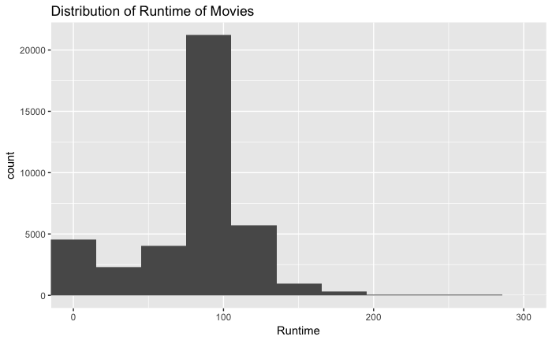

```r
budgetVSruntime <- data.frame(df2$Runtime , df2$Budget)
colnames(budgetVSruntime) <- c("duration", "budget")
yearVSruntime <- data.frame(df2$Runtime, df2$Year)
colnames(yearVSruntime) <- c("duration", "year")
##histogram of movies by duration
ggplot(df2, aes(Runtime)) + geom_histogram() + ggtitle("Distribution of Runtime of Movies") + coord_cartesian(xlim = c(0, 300))
```

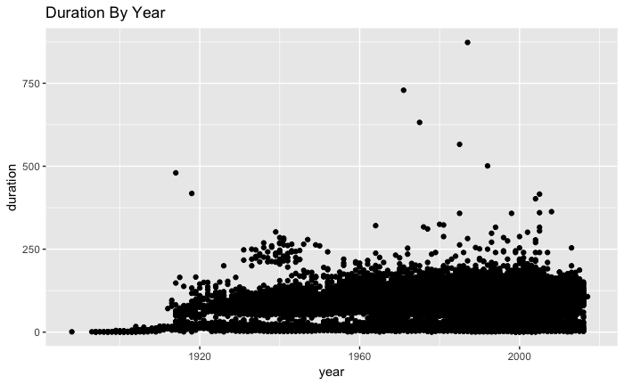

```r
###plot runtime vs year
ggplot(data = yearVSruntime, aes(year, duration)) + geom_point() + ggtitle("Duration By Year")
```

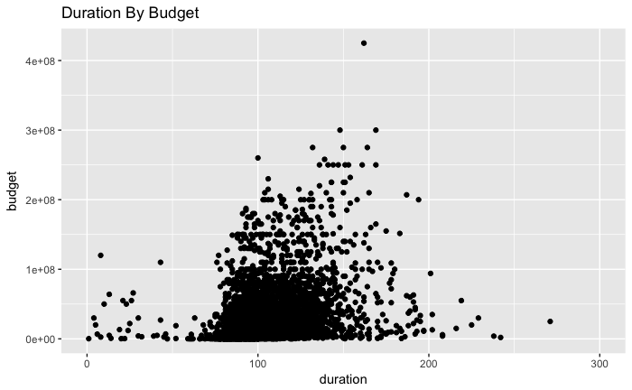

```r
###plot runtime vs budget
ggplot(data = budgetVSruntime, aes(duration, budget)) + geom_point() + ggtitle("Duration By Budget")+ coord_cartesian(xlim = c(0, 300))
```

**Q**: Comment on the distribution as well as relationships. Are there any patterns or trends that you can observe?

**A**: **A**: You can clearly see that the majority of movies are around 100 minutes in duration. Movies seem to get longer in duration by year, though eventually plateauing. Also, it seems as if most movies with large budgets (and movies in general) fall within the 60-150 minutes range. Very long and very short movies tend to have small budget.

## 3. Encode `Genre` column

The column `Genre` represents a list of genres associated with the movie in a string format. Write code to parse each text string into a binary vector with 1s representing the presence of a genre and 0s the absence, and add it to the dataframe as additional columns. Then remove the original `Genre` column.

For example, if there are a total of 3 genres: Drama, Comedy, and Action, a movie that is both Action and Comedy should be represented by a binary vector <0, 1, 1>. Note that you need to first compile a dictionary of all possible genres and then figure out which movie has which genres (you can use the R `tm` package to create the dictionary).

```r
# TODO: Replace Genre with a collection of binary columns
library(tm)
##manipulate genre as document
genre = VCorpus(VectorSource(df2$Genre))
##lowercase
genre = tm_map(genre, content_transformer(tolower))
##remove NAs
genre = tm_map(genre, removeWords, c("N/A"))
##removePunctuation
genre = tm_map(genre, removePunctuation)
##frequency of occurences (generate docterm mat.)
genreDTM = DocumentTermMatrix(genre)
genreMatrix = as.data.frame(as.matrix(genreDTM))
df2 = merge(genreMatrix, df2, by=0, all=TRUE)
```

```
column name ‘Row.names’ is duplicated in the result
```

Plot the relative proportions of movies having the top 10 most common genres.

```
Ignoring unknown parameters: binwidth, bins, pad
```

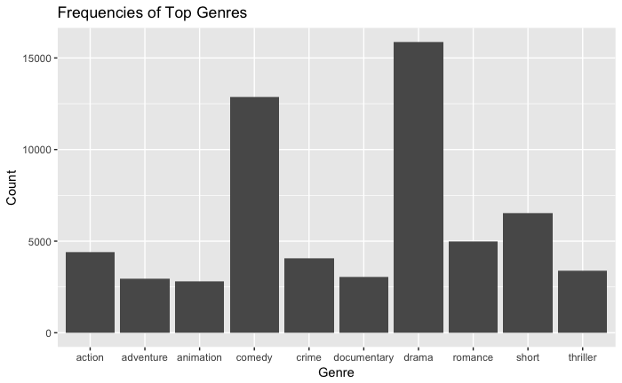

```r
# TODO: Select movies from top 10 most common genres and plot their relative proportions
#generate freq
genreFreq = colSums(genreMatrix)
#make data frame, order data and use top 10 common genres
genreFrame = data.frame(names(genreFreq[order(genreFreq,decreasing = TRUE)][1:10]),
                        genreFreq[order(genreFreq,decreasing = TRUE)][1:10])
colnames(genreFrame) = c("Genre","Count")
ggplot(genreFrame) + geom_histogram(aes(x = Genre, y = Count), stat = "identity") + ggtitle("Frequencies of Top Genres")
```

Examine how the distribution of `Runtime` changes across genres for the top 10 most common genres.

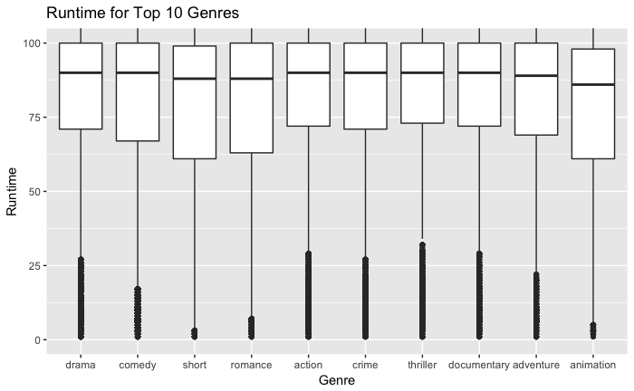

```r
# TODO: Plot Runtime distribution for top 10 most common genres
runtimeGenres = melt(df2, id.vars = c("Genre","Runtime"), measure.vars = c(names(genreFreq[order(genreFreq,decreasing = TRUE)][1:10])))
runtimeGenres = runtimeGenres[runtimeGenres$value!= 0,]
runtimeGenres = runtimeGenres[!is.na(runtimeGenres$Runtime),]
ggplot(runtimeGenres, aes(variable, Runtime)) + geom_boxplot() + coord_flip() + scale_y_continuous(labels = scales::comma) + xlab("Genre") + ggtitle("Runtime for Top 10 Genres") + coord_cartesian(ylim = c(0, 100))
```

```r
#Most genres tend to have similar runtimes, with medians just below 100 minutes roughly on average. Theres a significant amount of outliers beetween 150 and 200 minutes.
# TODO: Plot Runtime distribution for top 10 most common genres
# Let's prepare our data
```

**Q**: Describe the interesting relationship(s) you observe. Are there any expected or unexpected trends that are evident?

**A**: This one is a bit troubling, showing that all of the movies have a roughly similar runtime, and a third quartile of 100 minutes. This raises several questions – such as obvious ones like, “Why do shorts have the same median value as every other kind of movie? When this code was run before, it generated a graph that made better sense, and wrote the following analysis below, however for some reason my code is not reproducing the results I once had.

Running with the graph produced however, It seems as if shorts atleast have a smaller 3rd quartile range than others, suggesting that they have a shorter runtime than the median would suggest, and that animations as well would tend to be shorter. Action, thriller, Drama, Documentary, crime, and adventure movies will tend to not venture into small ranges of runtime. Shorts and animation seem to tend lower than the others.

## 4. Eliminate mismatched rows

The dataframe was put together by merging two different sources of data and it is possible that the merging process was inaccurate in some cases (the merge was done based on movie title, but there are cases of different movies with the same title). There are 3 columns that contain date information: `Year` (numeric year), `Date` (numeric year), and `Released` (string representation of the release date).

Find and remove all rows where you suspect a merge error occurred based on a mismatch between these variables. To make sure subsequent analysis and modeling work well, avoid removing more than 10% of the rows that have a `Gross` value present.

*Note: Do not remove the rows with `Gross == NA` at this point, just use this a guideline.*

```r
# TODO: Remove rows with Year/Date/Released mismatch
print("Rows")
```

```
[1] "Rows"
```

```r
dim(df2)[1]
```

```
[1] 42730
```

```r
#rows with na value for release date
naReleased = rownames(df2[is.na(df2$Released),])
#rid na dates from movies data
dates = setdiff(rownames(df2),naReleased)
df2 = df2[dates,]
print('Rows minus N/A rows')
```

```
[1] "Rows minus N/A rows"
```

```r
dim(df2)[1]
```

```
[1] 35051
```

```r
#rid mismatched dates from dadta
df2=df2[abs((df2$Year-as.numeric(substr(df2$Released, 1, 4))))<=1,]
print('Rows minus mismatached rows')
```

```
[1] "Rows minus mismatached rows"
```

```r
dim(df2)[1]
```

```
[1] 33232
```

**Q**: What is your precise removal logic, and how many rows remain in the resulting dataset?

The first step is to remove any data that has a na value for the date. Then the code checks for the years to be within 1 year of each other, else remove it. The resulting dataset still contains 33232 rows.

**A**:

## 5. Explore `Gross` revenue

For the commercial success of a movie, production houses want to maximize Gross revenue. Investigate if Gross revenue is related to Budget, Runtime or Genre in any way.

*Note: To get a meaningful relationship, you may have to partition the movies into subsets such as short vs. long duration, or by genre, etc.*

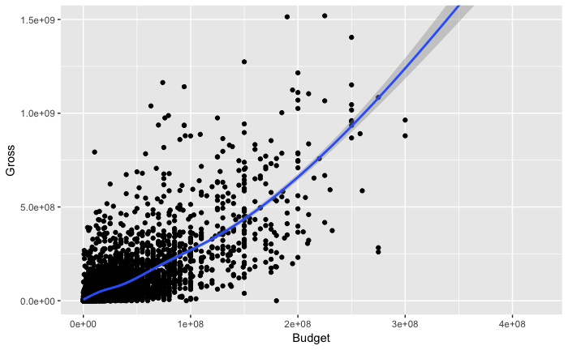

```r
# TODO: Investigate if Gross Revenue is related to Budget, Runtime or Genre
#plot gross v budget
ggplot(df2, aes(x=Budget, y=Gross))+
  geom_point()+
  geom_smooth()+ coord_cartesian(xlim = c(15000000,200000000))+ coord_cartesian(ylim = c(0, 1500000000))
```

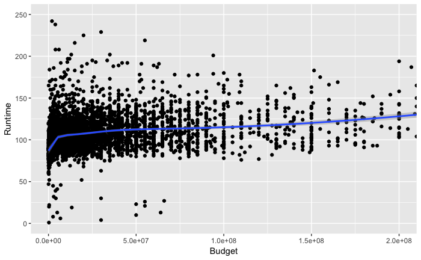

```r
#plot gross v rntime
ggplot(df2, aes(x=Budget, y=Runtime))+
  geom_point()+
  geom_smooth()+ coord_cartesian(xlim = c(0, 200000000),ylim = c(0,250))
```

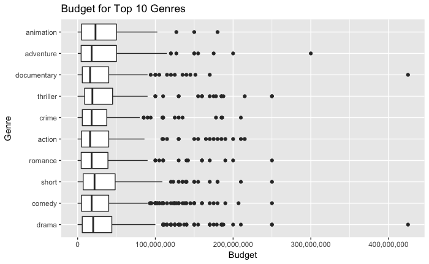

```r
#plt grs v genre
budgetGenres = melt(df2, id.vars = c("Genre","Budget"), measure.vars = c(names(genreFreq[order(genreFreq,decreasing = TRUE)][1:10])))
budgetGenres = budgetGenres[budgetGenres$value!= 0,]
budgetGenres = budgetGenres[!is.na(budgetGenres$Budget),]
ggplot(budgetGenres, aes(variable, Budget)) + geom_boxplot() + coord_flip() + scale_y_continuous(labels = scales::comma) + xlab("Genre") + ggtitle("Budget for Top 10 Genres")
```

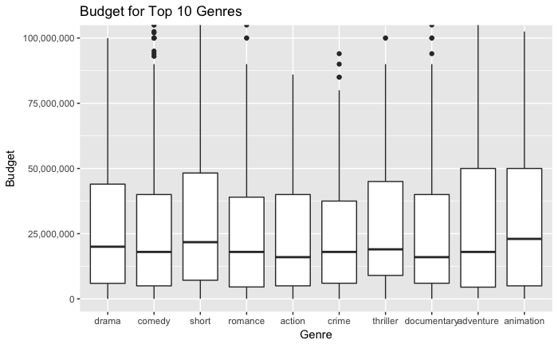

```r
ggplot(budgetGenres, aes(variable, Budget)) + geom_boxplot() + scale_y_continuous(labels = scales::comma) + xlab("Genre") + ggtitle("Budget for Top 10 Genres")   + coord_cartesian(ylim = c(0, 100000000))
```

**Q**: Did you find any observable relationships or combinations of Budget/Runtime/Genre that result in high Gross revenue? If you divided the movies into different subsets, you may get different answers for them - point out interesting ones.

**A**: The runtime on average stays roughly around 100 minutes until the budget becomes larger than 1e+08, where the runtime begins to mildly increase. Movies with very small budgets tend to have a notably shorter runtime. When looking at Gross vs. Budget, there is an extremely favorable relationship between budget and gross. One can clearly find that larger budgets tend to offer a favorable return on investment for a movie.

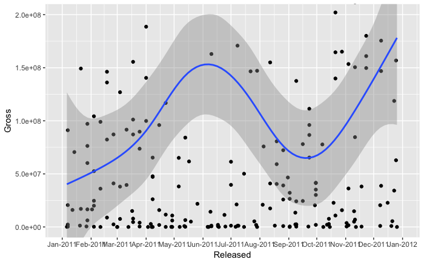

```r
# TODO: Investigate if Gross Revenue is related to Release Month
ggplot(df2, aes(x=Released,y=Gross))+
  geom_point()+
  geom_smooth()+scale_x_date(date_breaks = "1 month",
                 labels=date_format("%b-%Y"),
                 limits = as.Date(c('2011-01-01','2012-01-01')))+ coord_cartesian(ylim = c(0,200000000))
```

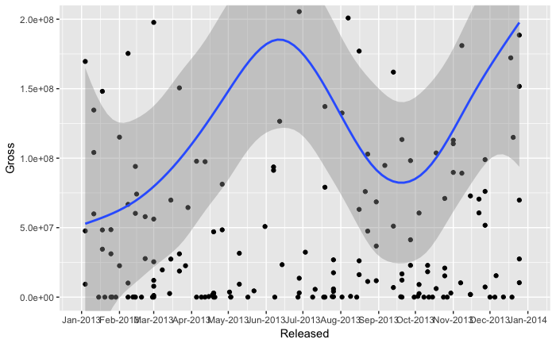

```r
ggplot(df2, aes(x=Released,y=Gross))+
  geom_point()+
  geom_smooth()+scale_x_date(date_breaks = "1 month",
                 labels=date_format("%b-%Y"),
                 limits = as.Date(c('2013-01-01','2014-01-01')))+ coord_cartesian(ylim = c(0,200000000))
```

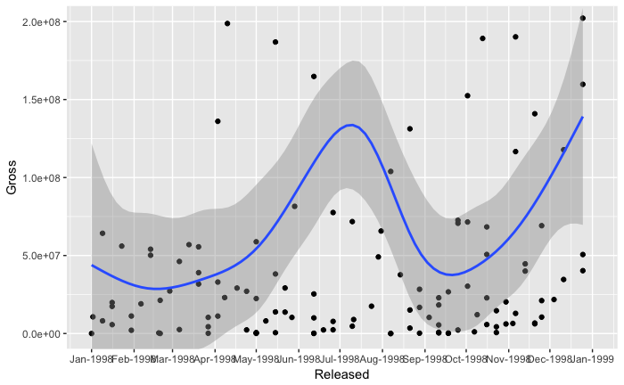

```r
ggplot(df2, aes(x=Released,y=Gross))+
  geom_point()+
  geom_smooth()+scale_x_date(date_breaks = "1 month",
                 labels=date_format("%b-%Y"),
                 limits = as.Date(c('1998-01-01','1999-01-01'))) + coord_cartesian(ylim = c(0,200000000))
```

The variable `Awards` describes nominations and awards in text format. Convert it to 2 numeric columns, the first capturing the number of wins, and the second capturing nominations. Replace the `Awards` column with these new columns, and then study the relationship of `Gross` revenue with respect to them.

*Note: The format of the `Awards` column is not standard; you may have to use regular expressions to find the relevant values. Try your best to process them, and you may leave the ones that don’t have enough information as NAs or set them to 0s.*

```r
# TODO: Convert Awards to 2 numeric columns: wins and nominations
#initialize an empty data frame for awards and nominations
awardsDF = data.frame(matrix(ncol = 2, nrow = dim(df2)[1] ))
colnames(awardsDF) = c("win", "nomination")
#loop over every element in the data
for (i in 1:dim(awardsDF)[1]){

  #split phrases into words
  disambig = unlist(strsplit(df2[i, "Awards"], split=" "))


  if(length(disambig) < 2) next

  for (j in 1:(length(disambig) - 1)){

    if (grepl("w",disambig[j+1])) {
      numWins = suppressWarnings(as.numeric(disambig[j]))
      awardsDF[i, "win"] = numWins

    }


    if (grepl("n",disambig[j+1])) {
        numNominations = suppressWarnings(as.numeric(disambig[j]))
        awardsDF[i, "nomination"] = numNominations
    }
  }


}
df2["win"] <-awardsDF[1]
df2["nomination"] <- awardsDF[2]
```

**Q**: How did you construct your conversion mechanism? How many rows had valid/non-zero wins or nominations?

**A**: We want to define two new colums in our dataset, for award and for nomination each. We then loop ovr the entire df2$Awards column and extract the numeric value preceding the word awards or the word nomination into their respective column.

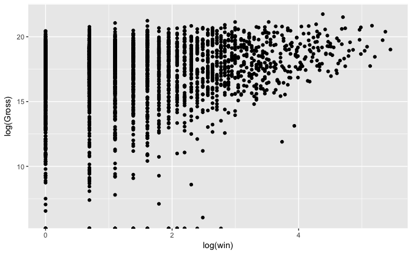

```r
# TODO: Plot Gross revenue against wins and nominations
#plotting the data without taking the log does not show a clear relationship.
#ggplot(df2,aes(win,Gross))+geom_point()# + coord_cartesian(xlim = c(0,200000000))
#ggplot(df2,aes(nomination,Gross))+geom_point()
ggplot(df2,aes(log(win),log(Gross)))+geom_point()
```

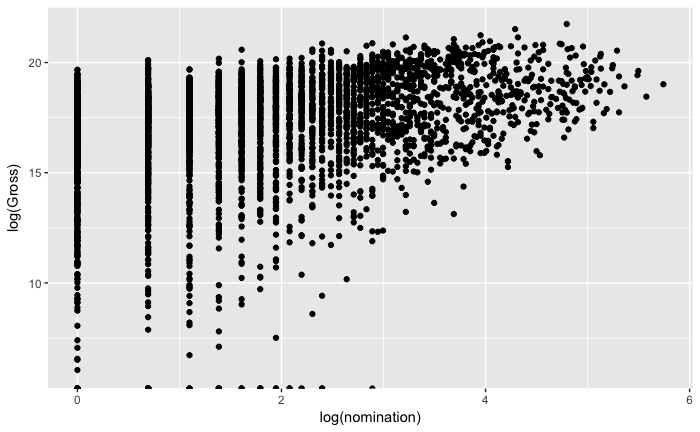

```r
ggplot(df2,aes(log(nomination),log(Gross)))+geom_point()
```

**Q**: How does the gross revenue vary by number of awards won and nominations received?

**A**: While winning many awards and nominations isn’t a prerequisite for having a large Gross, the data shows that there is a positive correlation between the amount of nominations and awards to the Gross. The movies with the most nominations and awards are concentrated in log(Gross) > 15.

## 7. Movie ratings from IMDb and Rotten Tomatoes

There are several variables that describe ratings, including IMDb ratings (`imdbRating` represents average user ratings and `imdbVotes` represents the number of user ratings), and multiple Rotten Tomatoes ratings (represented by several variables pre-fixed by `tomato`). Read up on such ratings on the web (for example rottentomatoes.com/about and www.imdb.com/help/show_leaf?votestopfaq).

Investigate the pairwise relationships between these different descriptors using graphs.

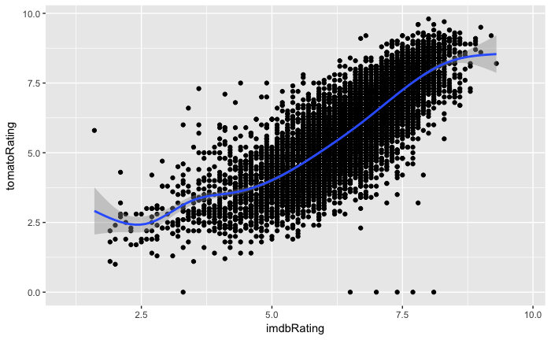

```r
# TODO: Illustrate how ratings from IMDb and Rotten Tomatoes are related
ggplot(df2, aes(x=imdbRating,y=tomatoRating))+
  geom_point()+
  geom_smooth()
```

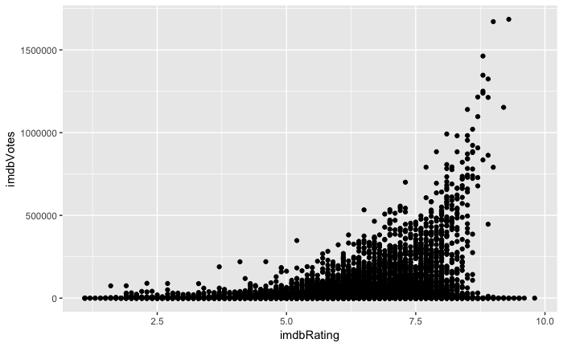

```r
ggplot(df2, aes(x=imdbRating,y=imdbVotes))+
  geom_point()
```

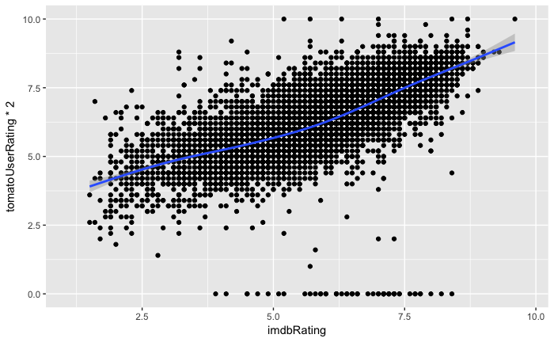

```r
ggplot(df2, aes(x=imdbRating,y=tomatoUserRating*2))+
  geom_point()+
  geom_smooth()
```

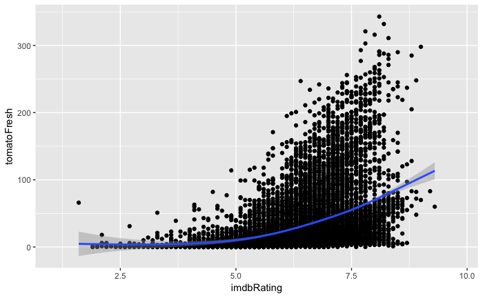

```r
ggplot(df2, aes(x=imdbRating,y=tomatoFresh))+
  geom_point()+     #there is a direct correlation between imdbrating and tomatoFresh
  geom_smooth()
```

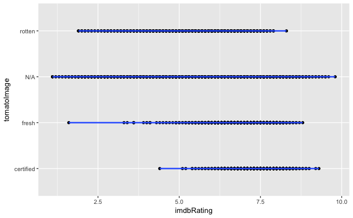

```r
ggplot(df2, aes(x=imdbRating,y=tomatoImage))+
  geom_point()+
  geom_smooth()
```

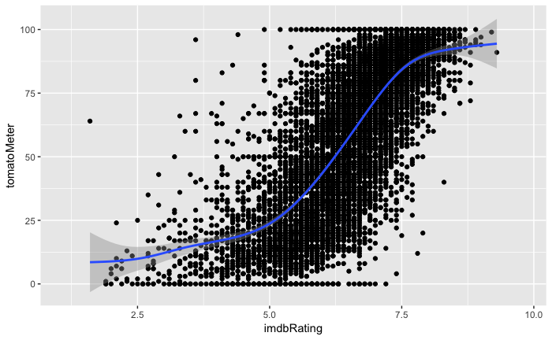

```r
ggplot(df2, aes(x=imdbRating,y=tomatoMeter))+
  geom_point()+
  geom_smooth()
```

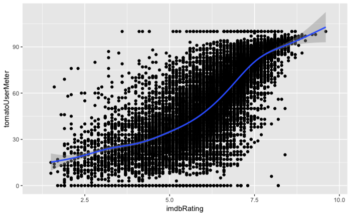

```r
ggplot(df2, aes(x=imdbRating,y=tomatoUserMeter))+
  geom_point()+
  geom_smooth()
```

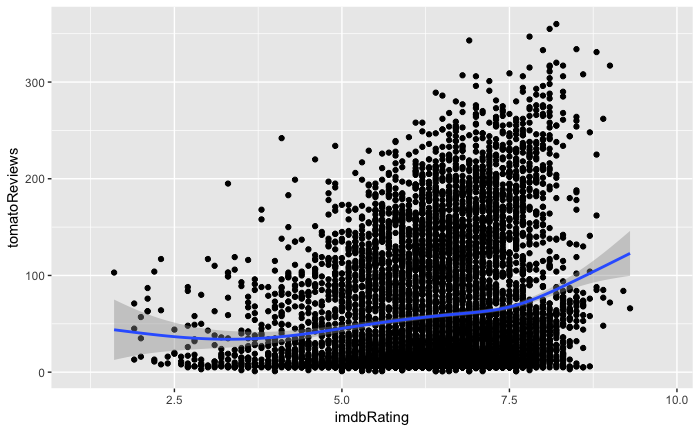

```r
ggplot(df2, aes(x=imdbRating,y=tomatoReviews))+
  geom_point()+
  geom_smooth()
```

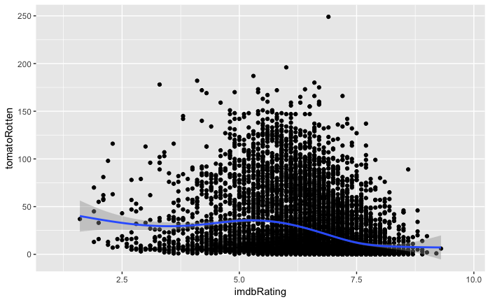

```r
ggplot(df2, aes(x=imdbRating,y=tomatoRotten))+
  geom_point()+
  geom_smooth()
```

```r
#comments, text based nonsense to plot.
#ggplot(df2, aes(x=imdbRating,y=tomatoConsensus))+
#  geom_point()+
#  geom_smooth()
#URLS, nonsense to plot
#ggplot(df2, aes(x=imdbRating,y=tomatoURL))+
#  geom_point()+
#  geom_smooth()
```

**Q**: Comment on the similarities and differences between the user ratings of IMDb and the critics ratings of Rotten Tomatoes.

## 8. Ratings and awards

These ratings typically reflect the general appeal of the movie to the public or gather opinions from a larger body of critics. Whereas awards are given by professional societies that may evaluate a movie on specific attributes, such as artistic performance, screenplay, sound design, etc.

Study the relationship between ratings and awards using graphs (awards here refers to wins and/or nominations).

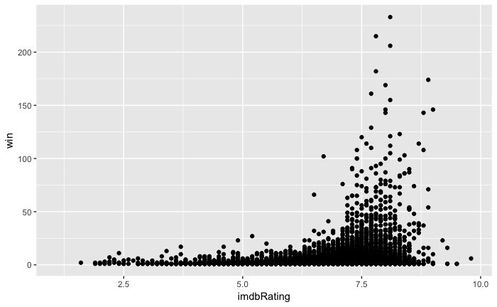

```r
# TODO: Show how ratings and awards are related
#plot ratings vs nominations
ggplot(df2,aes(imdbRating,win))+geom_point()
```

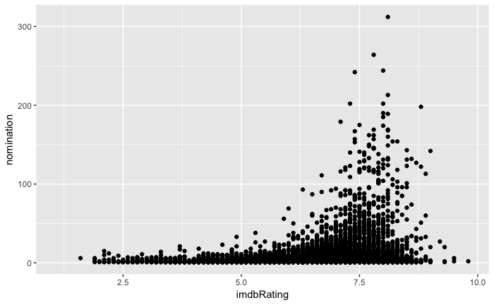

```r
#plot ratings vs awards
ggplot(df2,aes(imdbRating,nomination))+geom_point()
```

**Q**: How good are these ratings in terms of predicting the success of a movie in winning awards or nominations? Is there a high correlation between two variables?

**A**: There certainly is a high correlation between the two variables. Movies with under a 5.0 imdb rating are not likely to be nomimated or win an award, while movies after a 5.0 rating gain a seeming exponential amount of rewards. Few movies seem to achieve scores much higher than 8.75, and those that do tend towards relatively few awards. These movies are probably indie films with cult followings that are only well recieved in certain film sub-communities.

## 9. Expected insights

Come up with two new insights (backed up by data and graphs) that is expected. Here “new” means insights that are not an immediate consequence of one of the above tasks. You may use any of the columns already explored above or a different one in the dataset, such as `Title`, `Actors`, etc.

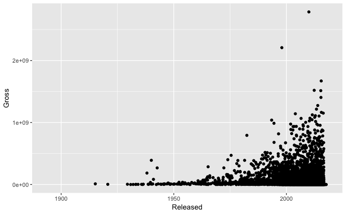

```r
# TODO: Find and illustrate two expected insights
ggplot(df2, aes(x=Released,y=Gross))+
  geom_point()
```

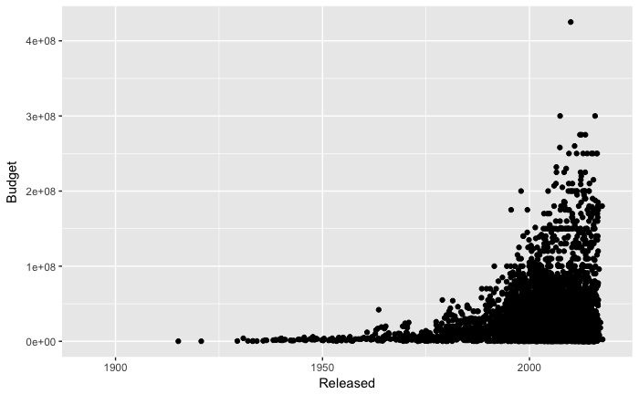

```r
ggplot(df2, aes(x=Released,y=Budget))+
  geom_point()
```

**Q**: Expected insight #1.

**Q**: Expected insight #2.

These two expected insights can give us an affirmation to an idea touched on in earlier analysis– that studios are reciprocated with a higher Gross if they increase their budget. Further analysis in how to optimize the budget would be very interesting.

## 10. Unexpected insight

Come up with one new insight (backed up by data and graphs) that is unexpected at first glance and do your best to motivate it. Same instructions apply as the previous task.

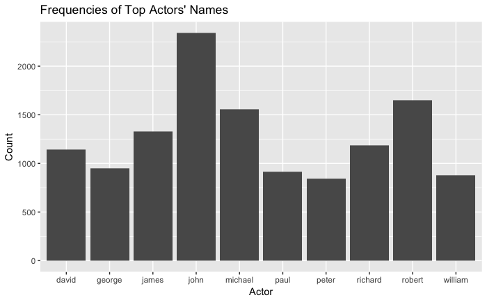

```r
# TODO: Find and illustrate one unexpected insight
##WARNING: the following code takes a few minutes to execute
actor = VCorpus(VectorSource(df2$Actors))
##remove NAs
actor = tm_map(actor, removeWords, c("N/A"))
actorDTM = DocumentTermMatrix(actor)
actorMatrix = as.data.frame(as.matrix(actorDTM))
###generate freq
actorFreq = colSums(actorMatrix)
actorFrame = data.frame(names(actorFreq[order(actorFreq,decreasing = TRUE)][1:10]),
                        actorFreq[order(actorFreq,decreasing = TRUE)][1:10])
colnames(actorFrame) = c("Actor","Count")
ggplot(actorFrame) + geom_bar(aes(x = Actor, y = Count), stat = "identity") + ggtitle("Frequencies of Top Actors' Names")
```

**Q**: Unexpected insight.

**A**: Plotting the most common first names of actors as a frequency shows that the first names of actors are typically biblical western male names, indicating that the data sourced is heavily skewed towards western produced movies, or even that the industry itself is skewed towards casting male leads with biblical names. Perhaps this could be read as this type of actor would be a safe investment for the studio.

Another interpretation is that perhaps in the wake of the success of movies such as Wonder Woman and Black Panther, indicators are present that the movie trends represented in this data are ready to be broken.

This data also probably not accounting for actors in asian markets, or perhaps is dealing with a serious skew in translating their names into English character. To typify the potential for such error, take the japanese katakana ゆ, which represents a common female name. It is pronounced “You”, and common spellings vary between Yu, Yū, Yuu, and perhaps even more further into Yuki or Yukari if using hiragana or kanji letter systems. The one japanese name, could produce 6 english results. Apart from the issues presented when translating between different language systems, there is an increased probability of incorrect data entry. With these complications, It could be a difficult, but economically rewarding task to create advacned methods for integrating names and titles properly between different language systems.